# Movie Memory Test

BRSM Mid-Semester Project Report

Vibe Coders

```r
library(readr)
library(dplyr)
library(ggplot2)
library(stringr)
library(scales)
library(readxl)
library(tibble)
library(tidyr)
library(purrr)
```

## 0.1 Encoding Time Exclusion

```r
tibble(
  Stage = c(
    "Initial N (files loaded into master dataframe)",
    paste0("Excluded - encoding time > ", encoding_threshold_min, " min"),
    "Final N for analysis"
  ),
  Count = c(
    n_total_loaded,
    n_encoding_excluded,
    n_after_encoding
  )
) %>% knitr::kable()
```

| Stage | Count |
| --- | --- |
| Initial N (files loaded into master dataframe) | 171 |
| Excluded - encoding time > 27.05 min | 5 |
| Final N for analysis | 166 |

**Encoding Time Exclusion Rationale:** Participants who took longer than 27.05 minutes between the end of video-watching instructions and the start of the recognition phase were excluded. Excessive delays suggest interruptions, technical issues, or anomalous session behavior that could compromise data quality. This window captures the complete 40-video encoding phase plus transition time.

```r
if (n_encoding_excluded > 0) {
  encoding_times %>%
    filter(participant_id %in% encoding_excluded_ids) %>%
    mutate(encoding_time_min = round(encoding_time_min, 1)) %>%
    select(`Participant` = participant_id, `Encoding Time (min)` = encoding_time_min) %>%
    knitr::kable(
      caption = "Participants excluded due to excessive encoding time"
    )
}
```

Participants excluded due to excessive encoding time

| Participant | Encoding Time (min) |
| --- | --- |
| sub148 | 27.1 |
| sub151 | 27.2 |
| sub161 | 28.0 |
| sub32 | 27.4 |
| sub36 | 27.8 |

# 1 Introduction

This report presents the analysis of a **movie memory test** (BRSM mid-semester project). The study investigates how the position of a video clip’s ending relative to a natural event boundary affects later recognition memory for individual video frames.

The theoretical foundation is **Event Segmentation Theory (EST; Zacks et al., 2007)**. When a natural event boundary is encountered, the current event model is updated and the prior model is consolidated into long-term memory, enhancing recognition memory for boundary-adjacent frames.

Participants watched short video clips ending at a natural event boundary (**NB** condition) or cut abruptly before the boundary (**AB** condition). They then completed a recognition memory test identifying the correct target frame from two alternatives.

# 2 Hypotheses and Variables

## 2.1 Research Hypotheses

**H1 - Condition effect on recognition accuracy:** NB participants will show significantly higher overall recognition accuracy than AB participants. Intact event boundaries strengthen memory encoding through event model updating.

**H2 - Boundary frame advantage:** NB-BB accuracy will be higher than AB-BB accuracy. The memory benefit of natural boundaries is linked specifically to boundary-adjacent frames.

**H3 - Event-middle frame null effect:** NB-EM and AB-EM accuracy will not differ significantly. If the boundary benefit is specific to boundary-adjacent frames, EM frames should be unaffected.

## 2.2 Variables

| Role | Variable | Type | Description |
| --- | --- | --- | --- |
| - | `participant_id` | Character | Unique participant identifier |
| - | `movie_id` | Integer (1-40) | Which of the 40 video clips the trial belongs to |
| **IV (between-subjects)** | `Condition` | Factor (NB/AB) | Natural Boundary vs Abrupt Boundary |
| **IV (within-subjects)** | `FrameType` | Factor (BB/EM) | Before-Boundary or Event-Middle probe frame |
| **Primary DV** | `Accuracy` | Numeric (0/1) | 1 if the target frame was correctly identified |
| **Secondary DV** | `RT` | Numeric (seconds) | Response time |
| **Secondary DV** | `Confidence` | Numeric | Self-rated confidence on the recognition decision |

## 2.3 Statistical Analysis Plan

### 2.3.1 Multiple Comparison Correction

Because we conduct **4 primary hypothesis tests** on the same dataset, we apply **Bonferroni correction** to control the family-wise error rate. Without correction, the probability of making at least one Type I error would be ~18.6% instead of the desired 5%.

$$\alpha_{adjusted} = \frac{0.05}{4} =
0.0125$$

This means **p-values must be < 0.0125** (not 0.05) to be considered statistically significant for Tests 1-4.

# 3 Data Cleaning and Preprocessing

## 3.1 Trial Count Exclusion

Each participant contributed one CSV file. After encoding time exclusion, participants were further excluded if their file contained fewer than 20 recognisable data rows, which would indicate an incomplete or corrupted recognition phase session.

```r
tibble(
  `Processing Stage` = c(
    "Participant CSV files loaded",
    paste0("Excluded - encoding time > ", encoding_threshold_min, " min"),
    "After encoding time filter",
    "Excluded - fewer than 20 valid data rows",
    "Final participant count for analysis"
  ),
  `Number of Participants` = c(
    n_total_loaded,
    n_encoding_excluded,
    n_after_encoding,
    n_excluded,
    n_included
  )
) %>% knitr::kable()
```

| Processing Stage | Number of Participants |
| --- | --- |
| Participant CSV files loaded | 171 |
| Excluded - encoding time > 27.05 min | 5 |
| After encoding time filter | 166 |
| Excluded - fewer than 20 valid data rows | 1 |
| Final participant count for analysis | 165 |

## 3.2 Variable Derivation

```r
trial_df <- clean_df %>%
  filter(!is.na(movie_id), !is.na(`resp.corr`)) %>%
  mutate(movie_id_num = suppressWarnings(as.integer(movie_id))) %>%
  filter(!is.na(movie_id_num), movie_id_num >= 1, movie_id_num <= 40) %>%
  mutate(
    Condition  = factor(str_to_upper(condition_raw), levels = c("NB", "AB")),
    FrameType  = factor(case_when(
      str_detect(target_img, "BB") ~ "BB",
      str_detect(target_img, "EM") ~ "EM",
      TRUE ~ NA_character_
    ), levels = c("BB", "EM")),
    Accuracy   = suppressWarnings(as.numeric(`resp.corr`)),
    RT         = suppressWarnings(as.numeric(str_trim(str_remove_all(`resp.rt`, "[\\[\\]\\s]")))),
    Confidence = suppressWarnings(as.numeric(`conf_radio.response`))
  ) %>%
  filter(!is.na(Accuracy), !is.na(Condition), !is.na(FrameType)) %>%
  select(participant_id, Condition, FrameType, movie_id = movie_id_num, Accuracy, RT, Confidence)

n_trials_before_rt <- nrow(trial_df)
rt_mean       <- mean(trial_df$RT, na.rm = TRUE)
rt_sd         <- sd(trial_df$RT,   na.rm = TRUE)
rt_cutoff     <- rt_mean + 3 * rt_sd
n_rt_outliers <- sum(!is.na(trial_df$RT) & trial_df$RT > rt_cutoff)
n_below_200ms <- sum(!is.na(trial_df$RT) & trial_df$RT < 0.2)

cat(sprintf("\n=== RT OUTLIER REMOVAL ===\n"))
```

```
##
## === RT OUTLIER REMOVAL ===
```

```r
cat(sprintf("Trials with RT < 200 ms (implausibly fast): %d\n", n_below_200ms))
```

```
## Trials with RT < 200 ms (implausibly fast): 0
```

```r
cat(sprintf("RT mean = %.0f ms, SD = %.0f ms\n", rt_mean * 1000, rt_sd * 1000))
```

```
## RT mean = 5679 ms, SD = 3783 ms
```

```r
cat(sprintf("Mean + 3SD cutoff = %.0f ms\n", rt_cutoff * 1000))
```

```
## Mean + 3SD cutoff = 17028 ms
```

```r
cat(sprintf("Trials removed (RT > Mean+3SD): %d (%.1f%%)\n", n_rt_outliers, 100 * n_rt_outliers / n_trials_before_rt))
```

```
## Trials removed (RT > Mean+3SD): 114 (1.7%)
```

```r
trial_df <- trial_df %>% filter(is.na(RT) | RT <= rt_cutoff)
cat("Final trial count after RT filter:", nrow(trial_df), "\n")
```

```
## Final trial count after RT filter: 6486
```

```r
cat("Final participant count:", n_distinct(trial_df$participant_id), "\n\n")
```

```
## Final participant count: 165
```

### 3.2.1 RT Outlier Removal Details

```r
tibble(
  Statistic = c(
    "Trials with RT < 200 ms (implausibly fast)",
    "RT mean",
    "RT SD",
    "Mean + 3SD cutoff",
    "Trials removed (RT > Mean+3SD)",
    "Final trial count after RT filter",
    "Final participant count"
  ),
  Value = c(
    paste0(n_below_200ms),
    paste0(round(rt_mean * 1000), " ms"),
    paste0(round(rt_sd * 1000), " ms"),
    paste0(round(rt_cutoff * 1000), " ms"),
    paste0(n_rt_outliers, " (", round(100 * n_rt_outliers / n_trials_before_rt, 1), "%)"),
    nrow(trial_df),
    n_distinct(trial_df$participant_id)
  )
) %>% knitr::kable()
```

| Statistic | Value |
| --- | --- |
| Trials with RT < 200 ms (implausibly fast) | 0 |
| RT mean | 5679 ms |
| RT SD | 3783 ms |
| Mean + 3SD cutoff | 17028 ms |
| Trials removed (RT > Mean+3SD) | 114 (1.7%) |
| Final trial count after RT filter | 6486 |
| Final participant count | 165 |

The table below tracks how many trials were removed at each cleaning step. Only rows with a valid `movie_id` (1–40), a recorded response, and a response time within three standard deviations of the mean were kept.

```r
n_after_participant <- nrow(clean_df)
n_initial_trials <- n_trials_before_rt
n_na_removed <- n_after_participant - n_initial_trials

tibble(
  Stage = c(
    "Total rows in loaded data (after participant exclusion)",
    "Rows removed - NA in movie_id or resp.corr (non-trial rows)",
    "Remaining recognition trials (movie_id 1-40)",
    "Trials with RT < 200 ms (implausibly fast) - none found",
    paste0("Trials excluded - RT > Mean+3SD (> ", round(rt_cutoff * 1000), " ms)"),
    "Final trial count for analysis"
  ),
  Count = c(
    n_after_participant,
    n_na_removed,
    n_initial_trials,
    n_below_200ms,
    n_rt_outliers,
    nrow(trial_df)
  )
) %>% knitr::kable()
```

| Stage | Count |
| --- | --- |
| Total rows in loaded data (after participant exclusion) | 7425 |
| Rows removed - NA in movie_id or resp.corr (non-trial rows) | 825 |
| Remaining recognition trials (movie_id 1-40) | 6600 |
| Trials with RT < 200 ms (implausibly fast) - none found | 0 |
| Trials excluded - RT > Mean+3SD (> 17028 ms) | 114 |
| Final trial count for analysis | 6486 |

## 3.3 Load Demographic Data

## 3.4 Participant Demographics

Of 185 register entries, **163 participants** had complete demographic records; **22** had no demographic information.

### 3.4.1 Comprehensive Descriptive Statistics - Demographics

#### 3.4.1.1 Age Statistics (Detailed)

```r
age_stats <- demo_complete %>%
  summarise(
    N                = n(),
    Mean             = mean(Age),
    Median           = median(Age),
    `Std Dev`        = sd(Age),
    Variance         = var(Age),
    `Std Error`      = sd(Age) / sqrt(n()),
    Minimum          = min(Age),
    Maximum          = max(Age),
    Range            = max(Age) - min(Age),
    Q1               = quantile(Age, 0.25),
    Q3               = quantile(Age, 0.75),
    IQR              = IQR(Age),
    `Coef of Var %`  = (sd(Age) / mean(Age)) * 100
  )

age_stats %>%
  pivot_longer(everything(), names_to = "Statistic", values_to = "Value") %>%
  mutate(Value = round(Value, 2)) %>%
  rename(`Age Statistic` = Statistic, `Value (years or count)` = Value)
```

| Age Statistic | Value (years or count) |
| --- | --- |
| N | 163.00 |
| Mean | 22.30 |
| Median | 22.00 |
| Std Dev | 2.31 |
| Variance | 5.33 |
| Std Error | 0.18 |
| Minimum | 19.00 |
| Maximum | 34.00 |
| Range | 15.00 |
| Q1 | 20.00 |
| Q3 | 23.00 |
| IQR | 3.00 |
| Coef of Var % | 10.36 |

**Interpretation:** The sample is predominantly young adults with mean age 22.3 years (SD = 2.3). The distribution spans from 19 to 34 years, with 50% of participants between 20 and 23 years (IQR).

#### 3.4.1.2 Age Distribution by Condition

```r
age_by_cond <- demo_complete %>%
  group_by(Condition) %>%
  summarise(
    N                    = n(),
    Mean                 = mean(Age),
    Median               = median(Age),
    `Std Dev`            = sd(Age),
    `Std Error`          = sd(Age) / sqrt(n()),
    Minimum              = min(Age),
    Maximum              = max(Age),
    Range                = max(Age) - min(Age),
    Q1                   = quantile(Age, 0.25),
    Q3                   = quantile(Age, 0.75),
    .groups = "drop"
  )

age_by_cond %>%
  mutate(across(where(is.numeric) & !N, ~round(.x, 2)))
```

| Condition | N | Mean | Median | Std Dev | Std Error | Minimum | Maximum | Range | Q1 | Q3 |
| --- | --- | --- | --- | --- | --- | --- | --- | --- | --- | --- |
| AB | 82 | 22.34 | 22 | 2.26 | 0.25 | 19 | 34 | 15 | 21 | 23 |
| NB | 81 | 22.26 | 22 | 2.38 | 0.26 | 19 | 28 | 9 | 20 | 24 |

**Key Finding:** Both conditions show remarkably similar age distributions, supporting successful randomization.

#### 3.4.1.3 Gender Frequency Distribution

```r
gender_freq <- demo_complete %>%
  count(Gender, name = "Frequency") %>%
  mutate(
    Percentage       = round((Frequency / sum(Frequency)) * 100, 1),
    `Cumulative %`   = round(cumsum(Percentage), 1)
  ) %>%
  arrange(desc(Frequency))

gender_freq
```

| Gender | Frequency | Percentage | Cumulative % |
| --- | --- | --- | --- |
| Male | 113 | 69.3 | 100.0 |
| Female | 50 | 30.7 | 30.7 |

**Summary:** The sample is 69.3% male and 30.7% female, reflecting a male-skewed convenience sample typical of certain university populations.

#### 3.4.1.4 Gender by Condition Cross-Tabulation

```r
gender_cond_table <- table(demo_complete$Gender, demo_complete$Condition)

gender_cond_df <- as.data.frame.matrix(gender_cond_table) %>%
  rownames_to_column("Gender") %>%
  mutate(
    Total        = NB + AB,
    `% of Total` = round((Total / sum(Total)) * 100, 1),
    `% within NB` = round((NB / sum(NB)) * 100, 1),
    `% within AB` = round((AB / sum(AB)) * 100, 1)
  )

gender_cond_df
```

| Gender | AB | NB | Total | % of Total | % within NB | % within AB |
| --- | --- | --- | --- | --- | --- | --- |
| Female | 27 | 23 | 50 | 30.7 | 28.4 | 32.9 |
| Male | 55 | 58 | 113 | 69.3 | 71.6 | 67.1 |

**Interpretation:** Gender distribution is balanced across conditions (Chi-squared test confirms no significant difference, see Test D2).

#### 3.4.1.5 Handedness Frequency Distribution

```r
handedness_freq <- demo_complete %>%
  count(Handedness, name = "Frequency") %>%
  mutate(
    Percentage       = round((Frequency / sum(Frequency)) * 100, 1),
    `Cumulative %`   = round(cumsum(Percentage), 1)
  ) %>%
  arrange(desc(Frequency))

handedness_freq
```

| Handedness | Frequency | Percentage | Cumulative % |
| --- | --- | --- | --- |
| Right handed | 154 | 94.5 | 100.0 |
| Left Handed | 9 | 5.5 | 5.5 |

#### 3.4.1.6 Handedness by Condition

```r
handedness_cond <- demo_complete %>%
  group_by(Condition, Handedness) %>%
  summarise(Count = n(), .groups = "drop") %>%
  group_by(Condition) %>%
  mutate(
    Total             = sum(Count),
    `Percentage`      = round((Count / Total) * 100, 1)
  ) %>%
  ungroup()

handedness_cond %>%
  select(Condition, Handedness, Count, Percentage) %>%
  arrange(Condition, desc(Count))
```

| Condition | Handedness | Count | Percentage |
| --- | --- | --- | --- |
| AB | Right handed | 79 | 96.3 |
| AB | Left Handed | 3 | 3.7 |
| NB | Right handed | 75 | 92.6 |
| NB | Left Handed | 6 | 7.4 |

#### 3.4.1.7 Vision Frequency Distribution

```r
vision_freq <- demo_complete %>%
  count(Vision, name = "Frequency") %>%
  mutate(
    Percentage       = round((Frequency / sum(Frequency)) * 100, 1),
    `Cumulative %`   = round(cumsum(Percentage), 1)
  ) %>%
  arrange(desc(Frequency))

vision_freq
```

| Vision | Frequency | Percentage | Cumulative % |
| --- | --- | --- | --- |
| Normal | 84 | 51.5 | 98.7 |
| Corrected to normal | 77 | 47.2 | 47.2 |
| Uncorrected vision difficulty | 2 | 1.2 | 99.9 |

**Summary:** Most participants have normal or corrected-to-normal vision (98.8%), ensuring visual stimuli were adequately perceived.

#### 3.4.1.8 Vision by Condition

```r
vision_cond <- demo_complete %>%
  group_by(Condition, Vision) %>%
  summarise(Count = n(), .groups = "drop") %>%
  group_by(Condition) %>%
  mutate(
    Total             = sum(Count),
    `Percentage`      = round((Count / Total) * 100, 1)
  ) %>%
  ungroup()

vision_cond %>%
  select(Condition, Vision, Count, Percentage) %>%
  arrange(Condition, desc(Count))
```

| Condition | Vision | Count | Percentage |
| --- | --- | --- | --- |
| AB | Normal | 44 | 53.7 |
| AB | Corrected to normal | 38 | 46.3 |
| NB | Normal | 40 | 49.4 |
| NB | Corrected to normal | 39 | 48.1 |
| NB | Uncorrected vision difficulty | 2 | 2.5 |

### 3.4.2 Summary Tables

The table below summarises the full sample. *Characteristic* = the demographic variable or category being described; *Value* = the corresponding count or statistic.

```r
tibble(
  `Demographic Characteristic` = c(
    "N — Number of participants with complete records",
    "Age — Mean (Standard Deviation)",
    "Age — Range (minimum to maximum)",
    "Gender — Female",
    "Gender — Male",
    "Handedness — Right-handed",
    "Handedness — Left-handed",
    "Vision — Normal (unaided)",
    "Vision — Corrected to normal (glasses or contact lenses)",
    "Vision — Uncorrected vision difficulty"
  ),
  `Value` = c(
    as.character(nrow(demo_complete)),
    sprintf("%.1f (%.1f)", mean(demo_complete$Age), sd(demo_complete$Age)),
    sprintf("%d – %d years", min(demo_complete$Age), max(demo_complete$Age)),
    as.character(sum(demo_complete$Gender == "Female", na.rm = TRUE)),
    as.character(sum(demo_complete$Gender == "Male",   na.rm = TRUE)),
    as.character(sum(demo_complete$Handedness == "Right handed", na.rm = TRUE)),
    as.character(sum(demo_complete$Handedness == "Left Handed",  na.rm = TRUE)),
    as.character(sum(demo_complete$Vision == "Normal",                        na.rm = TRUE)),
    as.character(sum(demo_complete$Vision == "Corrected to normal",           na.rm = TRUE)),
    as.character(sum(demo_complete$Vision == "Uncorrected vision difficulty", na.rm = TRUE))
  )
)
```

| Demographic Characteristic | Value |
| --- | --- |
| N — Number of participants with complete records | 163 |
| Age — Mean (Standard Deviation) | 22.3 (2.3) |
| Age — Range (minimum to maximum) | 19 – 34 years |
| Gender — Female | 50 |
| Gender — Male | 113 |
| Handedness — Right-handed | 154 |
| Handedness — Left-handed | 9 |
| Vision — Normal (unaided) | 84 |
| Vision — Corrected to normal (glasses or contact lenses) | 77 |
| Vision — Uncorrected vision difficulty | 2 |

The table below breaks down demographics by experimental condition. **NB** = Natural Boundary condition; **AB** = Abrupt Boundary condition. *Age Mean* and *Age Std Dev* are in years.

```r
demo_complete %>%
  group_by(Condition) %>%
  summarise(
    `Number of Participants` = n(),
    `Age Mean (years)`       = round(mean(Age), 1),
    `Age Std Dev (years)`    = round(sd(Age), 1),
    `Number Female`          = sum(Gender == "Female", na.rm = TRUE),
    `Number Male`            = sum(Gender == "Male",   na.rm = TRUE),
    `Right-handed`           = sum(Handedness == "Right handed", na.rm = TRUE),
    `Left-handed`            = sum(Handedness == "Left Handed",  na.rm = TRUE),
    .groups = "drop"
  )
```

| Condition | Number of Participants | Age Mean (years) | Age Std Dev (years) | Number Female | Number Male | Right-handed | Left-handed |
| --- | --- | --- | --- | --- | --- | --- | --- |
| AB | 82 | 22.3 | 2.3 | 27 | 55 | 79 | 3 |
| NB | 81 | 22.3 | 2.4 | 23 | 58 | 75 | 6 |

## 3.5 Participant-Level Aggregation

For statistical testing, **trial-level data** must be aggregated to the **participant level**. This is necessary because:

1. **Independence assumption**: Statistical tests (t-tests) assume each data point is independent. Multiple trials from the same participant are not independent.
2. **Unit of analysis**: Our experimental unit is the *participant*, not individual trials. We randomly assigned participants (not trials) to conditions.
3. **Avoid pseudoreplication**: Using all trials would artificially inflate sample size and violate statistical assumptions.

### 3.5.1 Aggregation Strategy

Three aggregated datasets were created:

```r
participant_level <- trial_df %>%
  group_by(participant_id, Condition) %>%
  summarise(mean_accuracy = mean(Accuracy, na.rm = TRUE),
            mean_rt       = mean(RT,       na.rm = TRUE),
            .groups = "drop")

cat("Participant-level dataset created:\n")
```

```
## Participant-level dataset created:
```

```r
cat("  - Number of participants:", nrow(participant_level), "\n")
```

```
##   - Number of participants: 165
```

```r
cat("  - NB condition:", sum(participant_level$Condition == "NB"), "participants\n")
```

```
##   - NB condition: 87 participants
```

```r
cat("  - AB condition:", sum(participant_level$Condition == "AB"), "participants\n")
```

```
##   - AB condition: 78 participants
```

```r
cat("  - Variables: participant_id, Condition, mean_accuracy, mean_rt\n")
```

```
##   - Variables: participant_id, Condition, mean_accuracy, mean_rt
```

```r
participant_frametype <- trial_df %>%
  group_by(participant_id, Condition, FrameType) %>%
  summarise(mean_accuracy = mean(Accuracy, na.rm = TRUE), .groups = "drop")

cat("\nParticipant × FrameType dataset created:\n")
```

```
##
## Participant × FrameType dataset created:
```

```r
cat("  - Total rows:", nrow(participant_frametype), "\n")
```

```
##   - Total rows: 330
```

```r
cat("  - Variables: participant_id, Condition, FrameType, mean_accuracy\n")
```

```
##   - Variables: participant_id, Condition, FrameType, mean_accuracy
```

```r
cat("  - Used for: BB vs EM frame type analyses\n")
```

```
##   - Used for: BB vs EM frame type analyses
```

```r
participant_demo <- participant_level %>%
  left_join(
    demo_complete %>% select(participant_id, Age, Gender, Handedness, Vision),
    by = "participant_id"
  ) %>%
  filter(!is.na(Age))

cat("\nMerged demographic + performance dataset created:\n")
```

```
##
## Merged demographic + performance dataset created:
```

```r
cat("  - Participants with complete data:", nrow(participant_demo), "\n")
```

```
##   - Participants with complete data: 148
```

```r
cat("  - Variables: participant_id, Condition, mean_accuracy, mean_rt, Age, Gender, Handedness, Vision\n")
```

```
##   - Variables: participant_id, Condition, mean_accuracy, mean_rt, Age, Gender, Handedness, Vision
```

```r
cat("  - Used for: Demographic moderator analyses (Tests D3 & D4)\n")
```

```
##   - Used for: Demographic moderator analyses (Tests D3 & D4)
```

**Result:** Each participant contributes exactly **one data point** to each statistical test, satisfying the independence assumption.

## 3.6 Bonferroni Correction

### 3.6.1 Why Multiple Comparison Correction is Necessary

When conducting **multiple statistical tests** on the same dataset, the probability of making at least one **Type I error** (false positive) increases with each additional test. This is known as the **multiple comparisons problem** or **family-wise error rate (FWER) inflation**.

**Example:** If we set α = 0.05 for each test: - Probability of NOT making a Type I error on one test = 0.95 - Probability of NOT making a Type I error on 4 independent tests = 0.95<sup>4</sup> = 0.814 - **Probability of making AT LEAST ONE Type I error = 1 - 0.814 = 0.186 (18.6%)**

This means that with 4 tests, we have nearly a 1 in 5 chance of incorrectly rejecting at least one true null hypothesis!

### 3.6.2 Bonferroni Correction Solution

```r
n_tests        <- 4
alpha_raw      <- 0.05
alpha_adjusted <- alpha_raw / n_tests

cat("Multiple comparison correction:\n")
```

```
## Multiple comparison correction:
```

```r
cat("  - Number of primary hypothesis tests:", n_tests, "\n")
```

```
##   - Number of primary hypothesis tests: 4
```

```r
cat("  - Uncorrected alpha level:", alpha_raw, "\n")
```

```
##   - Uncorrected alpha level: 0.05
```

```r
cat("  - Bonferroni-adjusted alpha:", alpha_adjusted, "\n")
```

```
##   - Bonferroni-adjusted alpha: 0.0125
```

```r
cat("  - Interpretation: p-values must be <", alpha_adjusted, "to be significant\n")
```

```
##   - Interpretation: p-values must be < 0.0125 to be significant
```

### 3.6.3 Mathematical Formula

$$\alpha_{adjusted} =
\frac{\alpha_{family-wise}}{k} = \frac{0.05}{4} = 0.0125$$

Where: - $\alpha_{adjusted}$ = adjusted significance threshold for each individual test - $\alpha_{family-wise}$ = desired family-wise error rate (conventionally 0.05) - $k$ = number of tests in the family (4 primary hypothesis tests)

### 3.6.4 Why Bonferroni for This Study?

1. **Conservative but appropriate**: Protects against false discoveries when testing related hypotheses
2. **Simple and transparent**: Easy to implement and report
3. **Controls FWER**: Maintains overall Type I error rate at 5% across all 4 tests
4. **Standard in psychology**: Widely accepted method for planned comparisons

### 3.6.5 Which Tests Use Bonferroni?

**Primary hypothesis tests** (Bonferroni-adjusted α = 0.0125): - Test 1: Overall accuracy (NB vs AB) - Test 2: Overall RT (NB vs AB) - Test 3: BB frame accuracy (NB vs AB) - Test 4: EM frame accuracy (NB vs AB)

**Demographic tests** (unadjusted α = 0.05): - Tests D1-D4 use α = 0.05 because they are exploratory checks, not primary hypotheses - These assess randomization success and potential moderators - Not part of the “family” of confirmatory tests

**Trade-off:** Bonferroni correction reduces statistical power (increases Type II error risk), but this is acceptable to maintain confidence in positive findings.

## 3.7 Descriptive Statistics

### 3.7.1 Overall Accuracy by Condition

Each row is one experimental condition. Values are computed at the **participant level** (each participant contributes one mean accuracy score averaged across all their trials). **NB** = Natural Boundary; **AB** = Abrupt Boundary. Accuracy is expressed as a proportion (0 = all wrong, 1 = all correct).

```r
participant_level %>%
  group_by(Condition) %>%
  summarise(
    `Number of Participants`  = n(),
    `Mean Accuracy`           = round(mean(mean_accuracy), 3),
    `Standard Deviation`      = round(sd(mean_accuracy), 3),
    `Standard Error`          = round(sd(mean_accuracy) / sqrt(n()), 3),
    `Minimum Accuracy`        = round(min(mean_accuracy), 3),
    `Maximum Accuracy`        = round(max(mean_accuracy), 3),
    .groups = "drop"
  )
```

| Condition | Number of Participants | Mean Accuracy | Standard Deviation | Standard Error | Minimum Accuracy | Maximum Accuracy |
| --- | --- | --- | --- | --- | --- | --- |
| NB | 87 | 0.876 | 0.072 | 0.008 | 0.650 | 1 |
| AB | 78 | 0.843 | 0.082 | 0.009 | 0.575 | 1 |

### 3.7.2 Accuracy by Condition and Frame Type

Each row represents one Condition × Frame Type combination. **BB** = Before-Boundary frame (a frame adjacent to the event boundary); **EM** = Event-Middle frame (a frame from the middle of the event, away from the boundary). Accuracy is a proportion (0–1).

```r
participant_frametype %>%
  group_by(Condition, `Frame Type` = FrameType) %>%
  summarise(
    `Number of Participants` = n(),
    `Mean Accuracy`          = round(mean(mean_accuracy), 3),
    `Standard Deviation`     = round(sd(mean_accuracy), 3),
    `Standard Error`         = round(sd(mean_accuracy) / sqrt(n()), 3),
    .groups = "drop"
  )
```

| Condition | Frame Type | Number of Participants | Mean Accuracy | Standard Deviation | Standard Error |
| --- | --- | --- | --- | --- | --- |
| NB | BB | 87 | 0.863 | 0.095 | 0.010 |
| NB | EM | 87 | 0.890 | 0.079 | 0.008 |
| AB | BB | 78 | 0.826 | 0.107 | 0.012 |
| AB | EM | 78 | 0.860 | 0.091 | 0.010 |

### 3.7.3 Reaction Time and Confidence by Condition

Computed at the **trial level** (all retained trials pooled within each condition). *Response Time* is in seconds from image onset to key press. *Confidence Rating* is a 1–5 scale recorded immediately after each recognition response (1 = not at all confident, 5 = completely confident).

```r
trial_df %>%
  group_by(Condition) %>%
  summarise(
    `Number of Trials`            = n(),
    `Mean Response Time (s)`      = round(mean(RT, na.rm = TRUE), 3),
    `Std Dev Response Time (s)`   = round(sd(RT,   na.rm = TRUE), 3),
    `Mean Confidence Rating`      = round(mean(Confidence, na.rm = TRUE), 3),
    `Std Dev Confidence Rating`   = round(sd(Confidence,   na.rm = TRUE), 3),
    .groups = "drop"
  )
```

| Condition | Number of Trials | Mean Response Time (s) | Std Dev Response Time (s) | Mean Confidence Rating | Std Dev Confidence Rating |
| --- | --- | --- | --- | --- | --- |
| NB | 3414 | 5.422 | 2.793 | 4.227 | 1.082 |
| AB | 3072 | 5.312 | 2.827 | 4.089 | 1.169 |

# 4 Exploratory Data Analysis (EDA)

### 4.0.1 EDA 1 - Distribution of the Data

#### 4.0.1.1 Figure 1A - Histogram of Accuracy

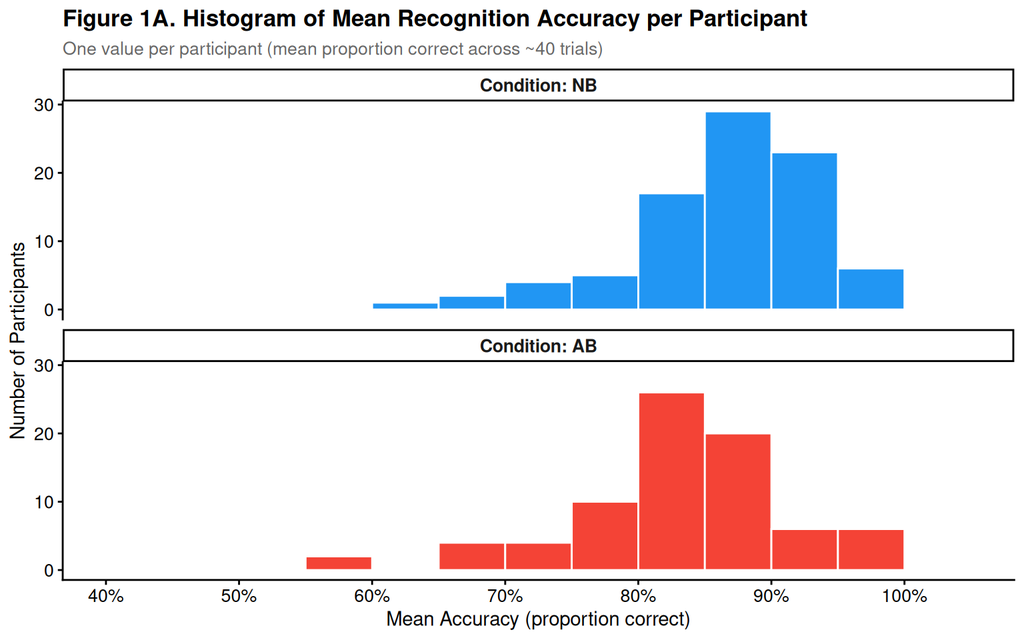

```r
p1a <- ggplot(participant_level, aes(x = mean_accuracy, fill = Condition)) +
  geom_histogram(binwidth = 0.05, colour = "white", boundary = 0) +
  facet_wrap(~Condition, ncol = 1, labeller = label_both) +
  scale_fill_manual(values = condition_colours) +
  scale_x_continuous(limits = c(0.4, 1.05), breaks = seq(0.4, 1.0, 0.1),
                     labels = scales::percent_format(accuracy = 1)) +
  labs(title = "Figure 1A. Histogram of Mean Recognition Accuracy per Participant",
       subtitle = "One value per participant (mean proportion correct across ~40 trials)",
       x = "Mean Accuracy (proportion correct)", y = "Number of Participants") +
  brsm_theme + theme(legend.position = "none")
print(p1a)
```

**Interpretation:** Both distributions are negatively skewed; most participants performed well above chance. NB distribution is shifted toward higher accuracy compared to AB.

#### 4.0.1.2 Figure 1B - Density Plot of Accuracy

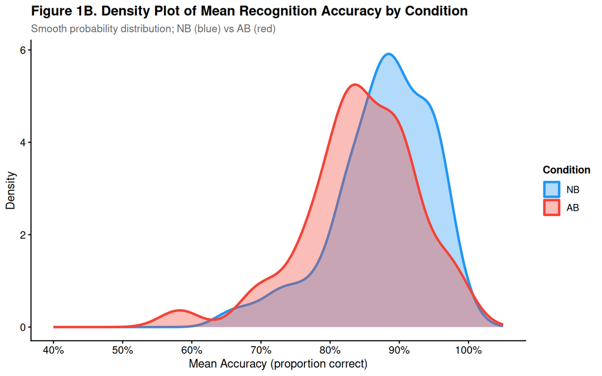

```r
p1b <- ggplot(participant_level, aes(x = mean_accuracy, fill = Condition, colour = Condition)) +
  geom_density(alpha = 0.35, linewidth = 1.1) +
  scale_fill_manual(values = condition_colours) +
  scale_colour_manual(values = condition_colours) +
  scale_x_continuous(limits = c(0.4, 1.05), breaks = seq(0.4, 1.0, 0.1),
                     labels = scales::percent_format(accuracy = 1)) +
  labs(title = "Figure 1B. Density Plot of Mean Recognition Accuracy by Condition",
       subtitle = "Smooth probability distribution; NB (blue) vs AB (red)",
       x = "Mean Accuracy (proportion correct)", y = "Density",
       fill = "Condition", colour = "Condition") +
  brsm_theme
print(p1b)
```

**Interpretation:** NB curve peaks slightly to the right of AB, indicating NB participants are concentrated at higher accuracy values.

### 4.0.2 EDA 2 - Differences Between Conditions

#### 4.0.2.1 Figure 2 - Violin Plot by Condition

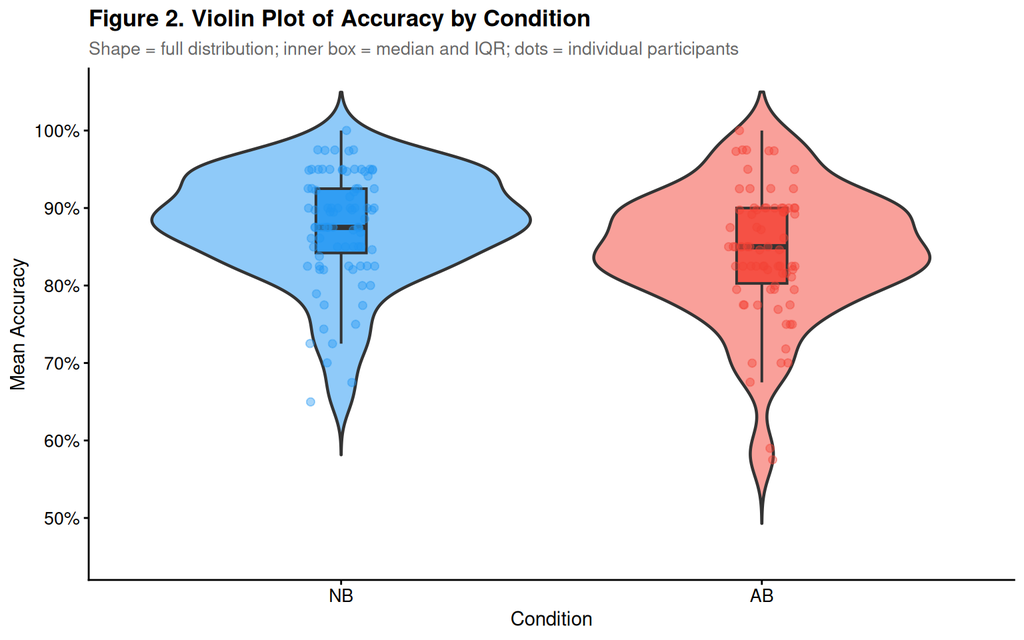

```r
p2a <- ggplot(participant_level, aes(x = Condition, y = mean_accuracy, fill = Condition)) +
  geom_violin(alpha = 0.5, trim = FALSE, linewidth = 0.8) +
  geom_boxplot(width = 0.12, outlier.shape = NA, alpha = 0.85, linewidth = 0.7) +
  geom_jitter(aes(colour = Condition), width = 0.08, alpha = 0.4, size = 1.8) +
  scale_fill_manual(values = condition_colours) +
  scale_colour_manual(values = condition_colours) +
  scale_y_continuous(limits = c(0.45, 1.05), breaks = seq(0.5, 1.0, 0.1),
                     labels = scales::percent_format(accuracy = 1)) +
  labs(title = "Figure 2. Violin Plot of Accuracy by Condition",
       subtitle = "Shape = full distribution; inner box = median and IQR; dots = individual participants",
       x = "Condition", y = "Mean Accuracy") +
  brsm_theme + theme(legend.position = "none")
print(p2a)
```

**Interpretation:** NB violin is wider at higher accuracy values and sits at a higher median than AB.

### 4.0.3 EDA 3 - Differences Between Frame Types

#### 4.0.3.1 Figure 3A - Violin Plot by Frame Type

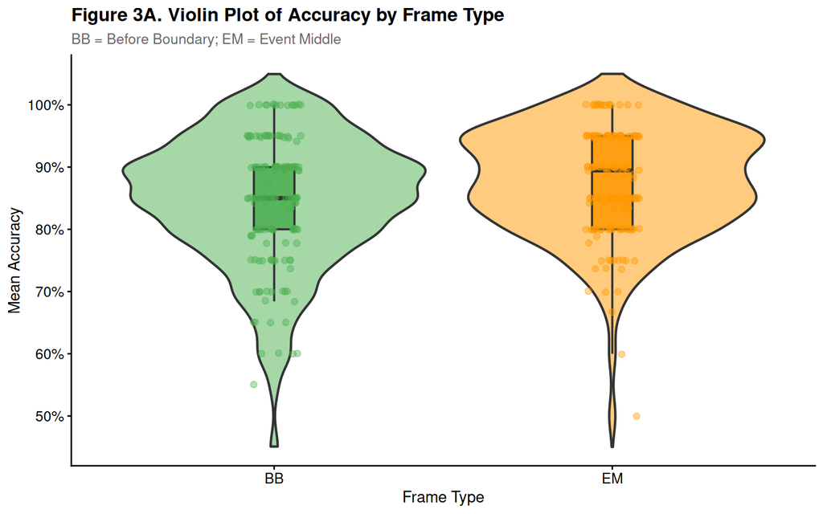

```r
p3a <- ggplot(participant_frametype, aes(x = FrameType, y = mean_accuracy, fill = FrameType)) +
  geom_violin(alpha = 0.5, trim = FALSE, linewidth = 0.8) +
  geom_boxplot(width = 0.12, outlier.shape = NA, alpha = 0.85, linewidth = 0.7) +
  geom_jitter(aes(colour = FrameType), width = 0.08, alpha = 0.4, size = 1.8) +
  scale_fill_manual(values = frametype_colours) +
  scale_colour_manual(values = frametype_colours) +
  scale_y_continuous(limits = c(0.45, 1.05), breaks = seq(0.5, 1.0, 0.1),
                     labels = scales::percent_format(accuracy = 1)) +
  labs(title = "Figure 3A. Violin Plot of Accuracy by Frame Type",
       subtitle = "BB = Before Boundary; EM = Event Middle",
       x = "Frame Type", y = "Mean Accuracy") +
  brsm_theme + theme(legend.position = "none")
print(p3a)
```

#### 4.0.3.2 Figure 3B - Heatmap of Mean Accuracy by Condition x Frame Type

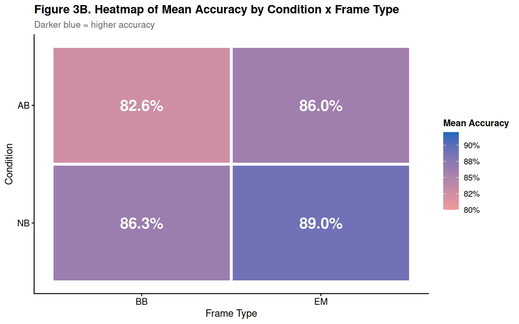

```r
interaction_means <- participant_frametype %>%
  group_by(Condition, FrameType) %>%
  summarise(N = n(), Mean = mean(mean_accuracy, na.rm = TRUE),
            SD = sd(mean_accuracy, na.rm = TRUE), SE = SD / sqrt(N),
            CI_low  = Mean - qt(0.975, df = N - 1) * SE,
            CI_high = Mean + qt(0.975, df = N - 1) * SE, .groups = "drop")

p3b <- ggplot(interaction_means, aes(x = FrameType, y = Condition, fill = Mean)) +
  geom_tile(colour = "white", linewidth = 1.5) +
  geom_text(aes(label = scales::percent(round(Mean, 3), accuracy = 0.1)),
            size = 6, fontface = "bold", colour = "white") +
  scale_fill_gradient(low = "#EF9A9A", high = "#1565C0", limits = c(0.80, 0.92),
                      labels = scales::percent_format(accuracy = 1)) +
  labs(title = "Figure 3B. Heatmap of Mean Accuracy by Condition x Frame Type",
       subtitle = "Darker blue = higher accuracy",
       x = "Frame Type", y = "Condition", fill = "Mean Accuracy") +
  brsm_theme
print(p3b)
```

### 4.0.4 EDA 4 - Group Means with Uncertainty (95% CI)

#### 4.0.4.1 Figure 4 - Bar Chart with 95% CI

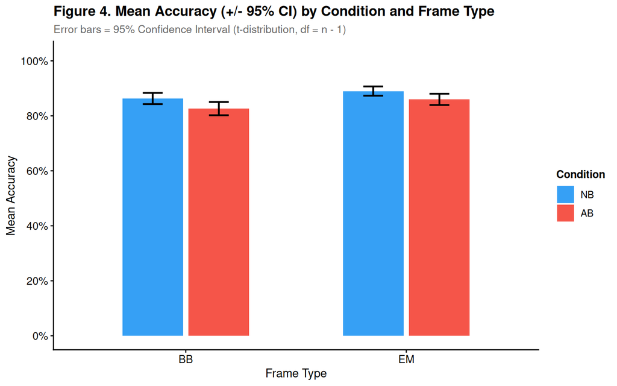

```r
p4 <- ggplot(interaction_means, aes(x = FrameType, y = Mean, fill = Condition)) +
  geom_col(position = position_dodge(width = 0.6), width = 0.55, alpha = 0.9) +
  geom_errorbar(aes(ymin = CI_low, ymax = CI_high),
                position = position_dodge(width = 0.6), width = 0.18, linewidth = 0.8) +
  scale_fill_manual(values = condition_colours) +
  scale_y_continuous(limits = c(0, 1.02), breaks = seq(0, 1, 0.2),
                     labels = scales::percent_format(accuracy = 1)) +
  labs(title = "Figure 4. Mean Accuracy (+/- 95% CI) by Condition and Frame Type",
       subtitle = "Error bars = 95% Confidence Interval (t-distribution, df = n - 1)",
       x = "Frame Type", y = "Mean Accuracy", fill = "Condition") +
  brsm_theme
print(p4)
```

### 4.0.5 EDA 5 - Participant Demographics

#### 4.0.5.1 Figure 5A - Age Distribution by Condition

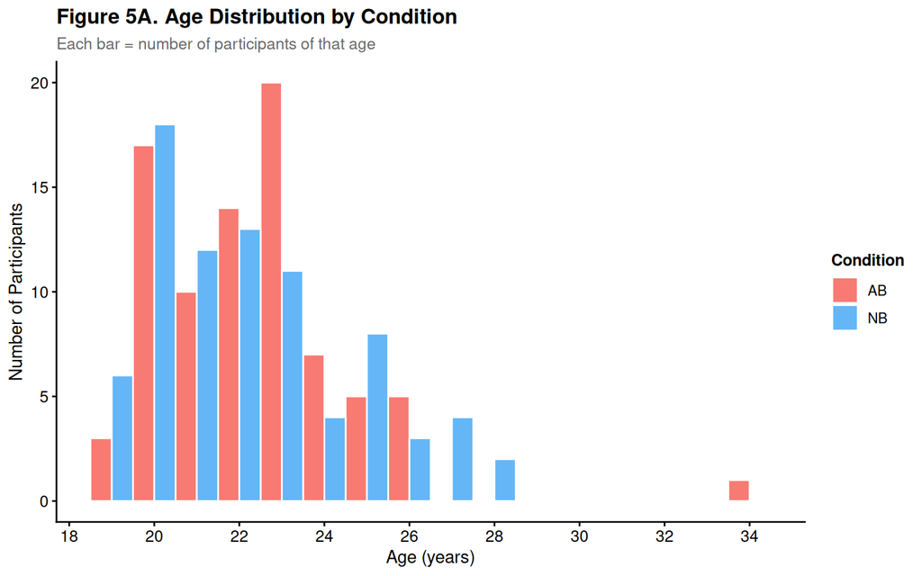

```r
p5a <- ggplot(demo_complete, aes(x = Age, fill = Condition)) +
  geom_histogram(binwidth = 1, position = "dodge", alpha = 0.7, colour = "white") +
  scale_fill_manual(values = condition_colours) +
  scale_x_continuous(breaks = seq(18, 36, 2)) +
  labs(title = "Figure 5A. Age Distribution by Condition",
       subtitle = "Each bar = number of participants of that age",
       x = "Age (years)", y = "Number of Participants", fill = "Condition") +
  brsm_theme
print(p5a)
```

#### 4.0.5.2 Figure 5B - Age Boxplot: NB vs AB

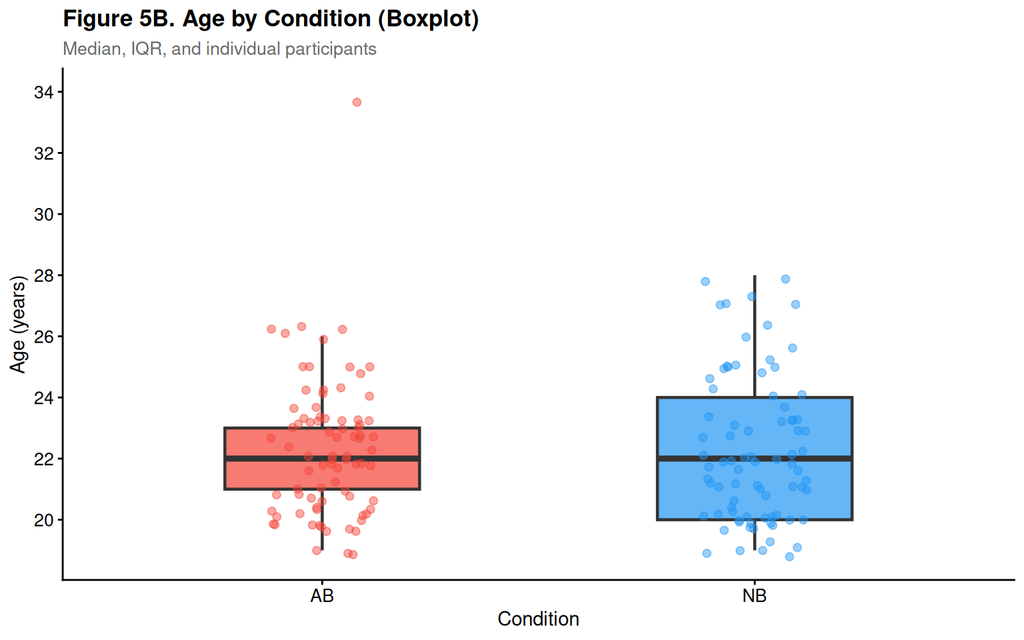

```r
p5b <- ggplot(demo_complete, aes(x = Condition, y = Age, fill = Condition)) +
  geom_boxplot(width = 0.45, outlier.shape = NA, alpha = 0.7, linewidth = 0.8) +
  geom_jitter(aes(colour = Condition), width = 0.12, alpha = 0.45, size = 1.8) +
  scale_fill_manual(values = condition_colours) +
  scale_colour_manual(values = condition_colours) +
  scale_y_continuous(breaks = seq(18, 36, 2)) +
  labs(title = "Figure 5B. Age by Condition (Boxplot)",
       subtitle = "Median, IQR, and individual participants",
       x = "Condition", y = "Age (years)") +
  brsm_theme + theme(legend.position = "none")
print(p5b)
```

**Interpretation:** Median age is virtually identical across NB and AB (both approximately 22 years).

#### 4.0.5.3 Figure 5C - Gender Breakdown (Overall)

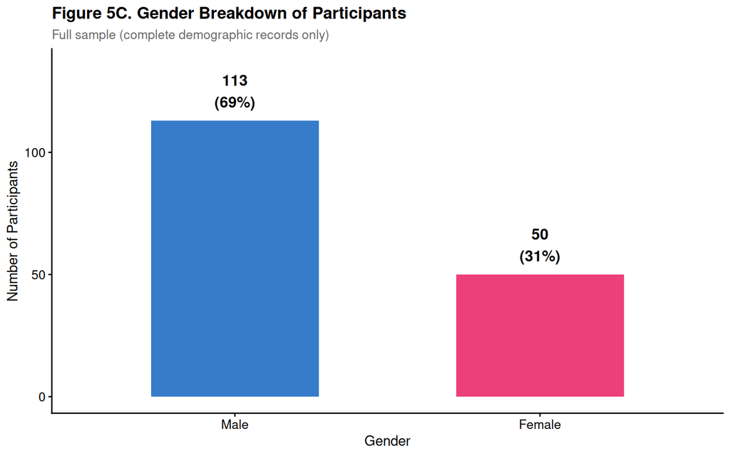

```r
gender_counts <- demo_complete %>% count(Gender) %>% mutate(pct = n / sum(n))

p5c <- ggplot(gender_counts, aes(x = reorder(Gender, -n), y = n, fill = Gender)) +
  geom_col(width = 0.55, alpha = 0.85) +
  geom_text(aes(label = sprintf("%d\n(%.0f%%)", n, pct * 100)), vjust = -0.4, size = 4.2, fontface = "bold") +
  scale_fill_manual(values = c("Female" = "#E91E63", "Male" = "#1565C0")) +
  scale_y_continuous(limits = c(0, max(gender_counts$n) * 1.2)) +
  labs(title = "Figure 5C. Gender Breakdown of Participants",
       subtitle = "Full sample (complete demographic records only)",
       x = "Gender", y = "Number of Participants") +
  brsm_theme + theme(legend.position = "none")
print(p5c)
```

**Interpretation:** Sample is predominantly male (113 vs 50 female). Typical of convenience samples from certain university departments.

#### 4.0.5.4 Figure 5D - Gender by Condition (Stacked Bar)

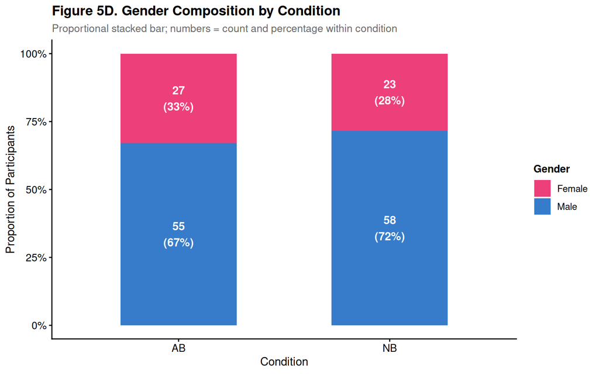

```r
gender_cond <- demo_complete %>%
  count(Condition, Gender) %>%
  group_by(Condition) %>% mutate(pct = n / sum(n)) %>% ungroup()

p5d <- ggplot(gender_cond, aes(x = Condition, y = pct, fill = Gender)) +
  geom_col(position = "stack", width = 0.55, alpha = 0.85) +
  geom_text(aes(label = sprintf("%d\n(%.0f%%)", n, pct * 100)),
            position = position_stack(vjust = 0.5), size = 3.8, fontface = "bold", colour = "white") +
  scale_fill_manual(values = c("Female" = "#E91E63", "Male" = "#1565C0")) +
  scale_y_continuous(labels = scales::percent_format(accuracy = 1)) +
  labs(title = "Figure 5D. Gender Composition by Condition",
       subtitle = "Proportional stacked bar; numbers = count and percentage within condition",
       x = "Condition", y = "Proportion of Participants", fill = "Gender") +
  brsm_theme
print(p5d)
```

**Interpretation:** Gender ratio is similar across both conditions (NB ~29% female; AB ~33% female).

#### 4.0.5.5 Figure 5E - Handedness Distribution

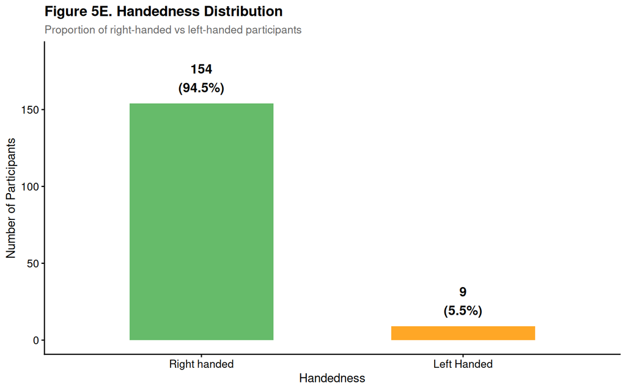

```r
handedness_counts <- demo_complete %>%
  count(Handedness) %>%
  mutate(pct = n / sum(n))

p5e <- ggplot(handedness_counts, aes(x = reorder(Handedness, -n), y = n, fill = Handedness)) +
  geom_col(width = 0.55, alpha = 0.85) +
  geom_text(aes(label = sprintf("%d\n(%.1f%%)", n, pct * 100)),
            vjust = -0.4, size = 4.2, fontface = "bold") +
  scale_fill_manual(values = c("Right handed" = "#4CAF50", "Left Handed" = "#FF9800")) +
  scale_y_continuous(limits = c(0, max(handedness_counts$n) * 1.2)) +
  labs(title = "Figure 5E. Handedness Distribution",
       subtitle = "Proportion of right-handed vs left-handed participants",
       x = "Handedness", y = "Number of Participants") +
  brsm_theme + theme(legend.position = "none")
print(p5e)
```

#### 4.0.5.6 Figure 5F - Vision Status Distribution

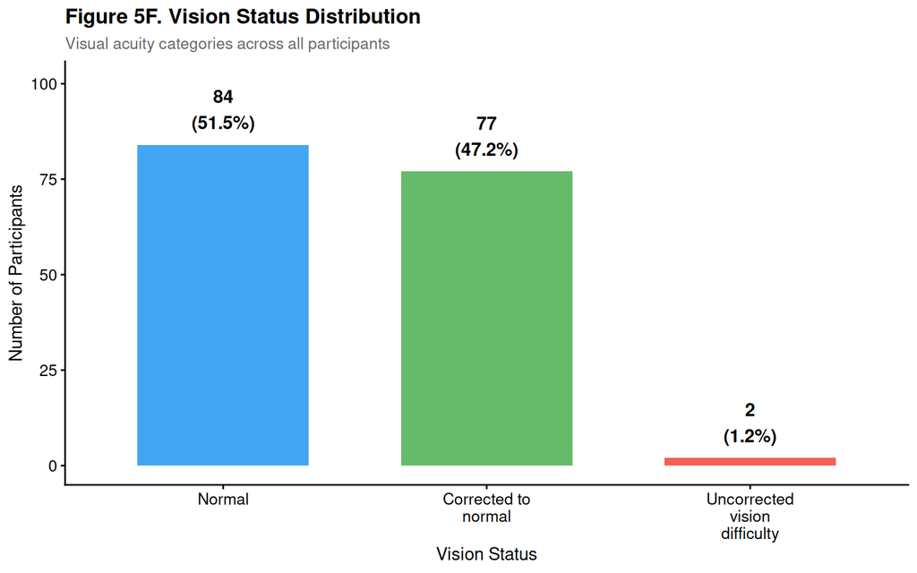

```r
vision_counts <- demo_complete %>%
  count(Vision) %>%
  mutate(pct = n / sum(n))

p5f <- ggplot(vision_counts, aes(x = reorder(Vision, -n), y = n, fill = Vision)) +
  geom_col(width = 0.65, alpha = 0.85) +
  geom_text(aes(label = sprintf("%d\n(%.1f%%)", n, pct * 100)),
            vjust = -0.4, size = 4, fontface = "bold") +
  scale_fill_manual(values = c("Normal" = "#2196F3",
                                "Corrected to normal" = "#4CAF50",
                                "Uncorrected vision difficulty" = "#F44336")) +
  scale_y_continuous(limits = c(0, max(vision_counts$n) * 1.2)) +
  scale_x_discrete(labels = function(x) str_wrap(x, width = 15)) +
  labs(title = "Figure 5F. Vision Status Distribution",
       subtitle = "Visual acuity categories across all participants",
       x = "Vision Status", y = "Number of Participants") +
  brsm_theme + theme(legend.position = "none")
print(p5f)
```

#### 4.0.5.7 Figure 5G - Age Distribution (Histogram + Density)

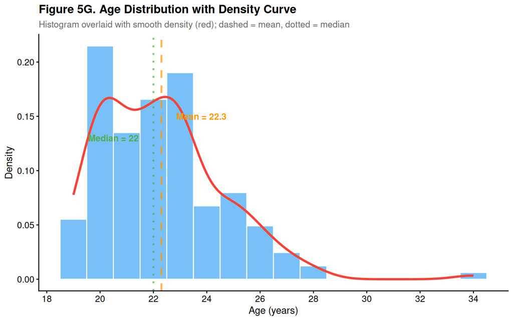

```r
p5g <- ggplot(demo_complete, aes(x = Age)) +
  geom_histogram(aes(y = after_stat(density)), binwidth = 1,
                 fill = "#2196F3", alpha = 0.6, colour = "white") +
  geom_density(linewidth = 1.2, colour = "#F44336") +
  geom_vline(aes(xintercept = mean(Age)), colour = "#FF9800",
             linetype = "dashed", linewidth = 1, alpha = 0.7) +
  geom_vline(aes(xintercept = median(Age)), colour = "#4CAF50",
             linetype = "dotted", linewidth = 1, alpha = 0.7) +
  annotate("text", x = mean(demo_complete$Age) + 1.5, y = 0.15,
           label = sprintf("Mean = %.1f", mean(demo_complete$Age)),
           colour = "#FF9800", fontface = "bold", size = 3.5) +
  annotate("text", x = median(demo_complete$Age) - 1.5, y = 0.13,
           label = sprintf("Median = %.0f", median(demo_complete$Age)),
           colour = "#4CAF50", fontface = "bold", size = 3.5) +
  scale_x_continuous(breaks = seq(18, 36, 2)) +
  labs(title = "Figure 5G. Age Distribution with Density Curve",
       subtitle = "Histogram overlaid with smooth density (red); dashed = mean, dotted = median",
       x = "Age (years)", y = "Density") +
  brsm_theme
print(p5g)
```

**Interpretation:** Age distribution is slightly right-skewed with concentration around 20-23 years. Mean and median are very close, suggesting near-normal distribution.

#### 4.0.5.8 Figure 5H - Demographic Summary Heatmap

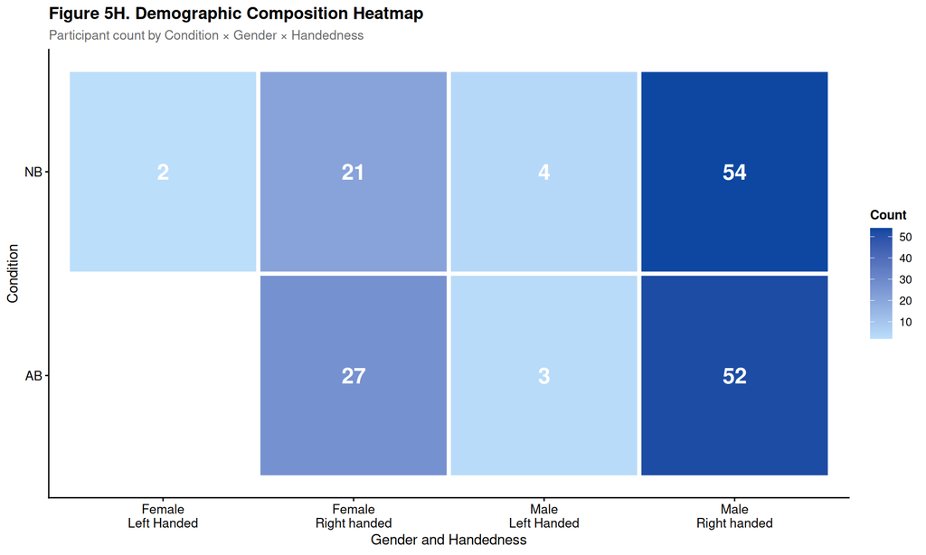

```r
# Create a summary matrix for heatmap
demo_matrix <- demo_complete %>%
  group_by(Condition, Gender, Handedness) %>%
  summarise(Count = n(), .groups = "drop")

p5h <- ggplot(demo_matrix, aes(x = paste(Gender, Handedness, sep = "\n"),
                                y = Condition, fill = Count)) +
  geom_tile(colour = "white", linewidth = 1.5) +
  geom_text(aes(label = Count), size = 6, fontface = "bold", colour = "white") +
  scale_fill_gradient(low = "#BBDEFB", high = "#0D47A1") +
  labs(title = "Figure 5H. Demographic Composition Heatmap",
       subtitle = "Participant count by Condition × Gender × Handedness",
       x = "Gender and Handedness", y = "Condition", fill = "Count") +
  brsm_theme +
  theme(axis.text.x = element_text(angle = 0, hjust = 0.5))
print(p5h)
```

# 5 Statistical Tests

## 5.1 Hypothesis Tests

**Reminder:** All four hypothesis tests use **Bonferroni-adjusted α = 0.0125** to control for multiple comparisons. A p-value must be less than 0.0125 (not 0.05) to be considered statistically significant.

### 5.1.1 Test 1 - Overall Recognition Accuracy: NB vs AB (H1)

```r
acc_NB <- participant_level %>% filter(Condition == "NB") %>% pull(mean_accuracy)
acc_AB <- participant_level %>% filter(Condition == "AB") %>% pull(mean_accuracy)
t1 <- t.test(acc_NB, acc_AB, var.equal = FALSE)
t1
```

```
##
##  Welch Two Sample t-test
##
## data:  acc_NB and acc_AB
## t = 2.7697, df = 153.65, p-value = 0.006303
## alternative hypothesis: true difference in means is not equal to 0
## 95 percent confidence interval:
##  0.00958610 0.05727949
## sample estimates:
## mean of x mean of y
## 0.8763936 0.8429608
```

### 5.1.2 Test 2 - Overall Response Time: NB vs AB (H1)

```r
rt_NB <- participant_level %>% filter(Condition == "NB") %>% pull(mean_rt)
rt_AB <- participant_level %>% filter(Condition == "AB") %>% pull(mean_rt)
t2 <- t.test(rt_NB, rt_AB, var.equal = FALSE)
t2
```

```
##
##  Welch Two Sample t-test
##
## data:  rt_NB and rt_AB
## t = 0.64798, df = 161.15, p-value = 0.5179
## alternative hypothesis: true difference in means is not equal to 0
## 95 percent confidence interval:
##  -0.2378427  0.4701533
## sample estimates:
## mean of x mean of y
##  5.447253  5.331097
```

### 5.1.3 Test 3 - Boundary Frame Accuracy: NB-BB vs AB-BB (H2)

```r
bb_NB <- participant_frametype %>% filter(Condition == "NB", FrameType == "BB") %>% pull(mean_accuracy)
bb_AB <- participant_frametype %>% filter(Condition == "AB", FrameType == "BB") %>% pull(mean_accuracy)
t3 <- t.test(bb_NB, bb_AB, var.equal = FALSE)
t3
```

```
##
##  Welch Two Sample t-test
##
## data:  bb_NB and bb_AB
## t = 2.3239, df = 155.14, p-value = 0.02143
## alternative hypothesis: true difference in means is not equal to 0
## 95 percent confidence interval:
##  0.005523778 0.068138047
## sample estimates:
## mean of x mean of y
## 0.8630380 0.8262071
```

### 5.1.4 Test 4 - Event-Middle Frame Accuracy: NB-EM vs AB-EM (H3)

```r
em_NB <- participant_frametype %>% filter(Condition == "NB", FrameType == "EM") %>% pull(mean_accuracy)
em_AB <- participant_frametype %>% filter(Condition == "AB", FrameType == "EM") %>% pull(mean_accuracy)
t4 <- t.test(em_NB, em_AB, var.equal = FALSE)
t4
```

```
##
##  Welch Two Sample t-test
##
## data:  em_NB and em_AB
## t = 2.2586, df = 153.6, p-value = 0.02531
## alternative hypothesis: true difference in means is not equal to 0
## 95 percent confidence interval:
##  0.003780158 0.056535410
## sample estimates:
## mean of x mean of y
## 0.8900506 0.8598928
```

## 5.2 Demographic Tests (D1-D4)

**Note:** Demographic tests use **unadjusted α = 0.05** because they are exploratory analyses checking randomization success and potential moderators, not confirmatory hypothesis tests. They are not part of the primary “family” of tests requiring Bonferroni correction.

### 5.2.1 Test D1 - Age Balance: NB vs AB (Randomisation Check)

```r
age_NB <- participant_demo %>% filter(Condition == "NB") %>% pull(Age)
age_AB <- participant_demo %>% filter(Condition == "AB") %>% pull(Age)
td1 <- t.test(age_NB, age_AB, var.equal = FALSE)
td1
```

```
##
##  Welch Two Sample t-test
##
## data:  age_NB and age_AB
## t = 0.41439, df = 137.87, p-value = 0.6792
## alternative hypothesis: true difference in means is not equal to 0
## 95 percent confidence interval:
##  -0.5435372  0.8317564
## sample estimates:
## mean of x mean of y
##  22.24000  22.09589
```

**Interpretation:** A non-significant result (p > 0.05) confirms age was balanced across conditions.

### 5.2.2 Test D2 - Gender Balance: NB vs AB (Randomisation Check)

```r
gender_table <- table(participant_demo$Gender, participant_demo$Condition)
print(gender_table)
```

```
##
##          NB AB
##   Female 22 23
##   Male   53 50
```

```r
td2 <- chisq.test(gender_table)
td2
```

```
##
##  Pearson's Chi-squared test with Yates' continuity correction
##
## data:  gender_table
## X-squared = 0.01181, df = 1, p-value = 0.9135
```

**Interpretation:** A non-significant chi-squared result confirms gender was distributed similarly across conditions.

### 5.2.3 Test D3 - Age as a Moderator of Recognition Accuracy

```r
td3 <- cor.test(participant_demo$Age, participant_demo$mean_accuracy, method = "pearson")
td3
```

```
##
##  Pearson's product-moment correlation
##
## data:  participant_demo$Age and participant_demo$mean_accuracy
## t = -1.5604, df = 146, p-value = 0.1208
## alternative hypothesis: true correlation is not equal to 0
## 95 percent confidence interval:
##  -0.28355947  0.03397068
## sample estimates:
##        cor
## -0.1280751
```

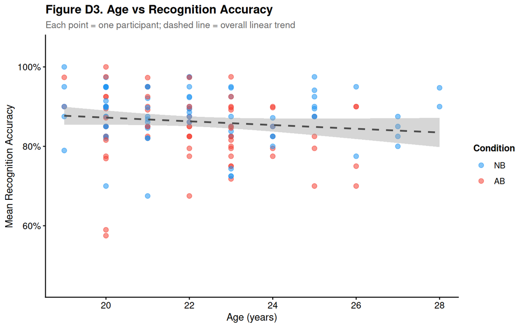

```r
p_d3 <- ggplot(participant_demo, aes(x = Age, y = mean_accuracy, colour = Condition)) +
  geom_point(alpha = 0.55, size = 2.2) +
  geom_smooth(method = "lm", se = TRUE, aes(group = 1), colour = "grey30", linewidth = 0.9, linetype = "dashed") +
  scale_colour_manual(values = condition_colours) +
  scale_y_continuous(limits = c(0.45, 1.05), labels = scales::percent_format(accuracy = 1)) +
  scale_x_continuous(breaks = seq(18, 36, 2)) +
  labs(title = "Figure D3. Age vs Recognition Accuracy",
       subtitle = "Each point = one participant; dashed line = overall linear trend",
       x = "Age (years)", y = "Mean Recognition Accuracy", colour = "Condition") +
  brsm_theme
print(p_d3)
```

**Interpretation:** In this narrow university-age sample (mean ~22 years), age is expected to be a negligible predictor of memory performance.

### 5.2.4 Test D4 - Gender as a Moderator of Recognition Accuracy

```r
acc_female <- participant_demo %>% filter(Gender == "Female") %>% pull(mean_accuracy)
acc_male   <- participant_demo %>% filter(Gender == "Male")   %>% pull(mean_accuracy)

cat("Female: n =", length(acc_female), "| M =", round(mean(acc_female), 3), "| SD =", round(sd(acc_female), 3), "\n")
```

```
## Female: n = 45 | M = 0.88 | SD = 0.072
```

```r
cat("Male:   n =", length(acc_male),   "| M =", round(mean(acc_male),   3), "| SD =", round(sd(acc_male),   3), "\n")
```

```
## Male:   n = 103 | M = 0.854 | SD = 0.079
```

```r
td4 <- t.test(acc_female, acc_male, var.equal = FALSE)
td4
```

```
##
##  Welch Two Sample t-test
##
## data:  acc_female and acc_male
## t = 1.9224, df = 90.907, p-value = 0.05768
## alternative hypothesis: true difference in means is not equal to 0
## 95 percent confidence interval:
##  -0.0008476419  0.0517770916
## sample estimates:
## mean of x mean of y
## 0.8798973 0.8544326
```

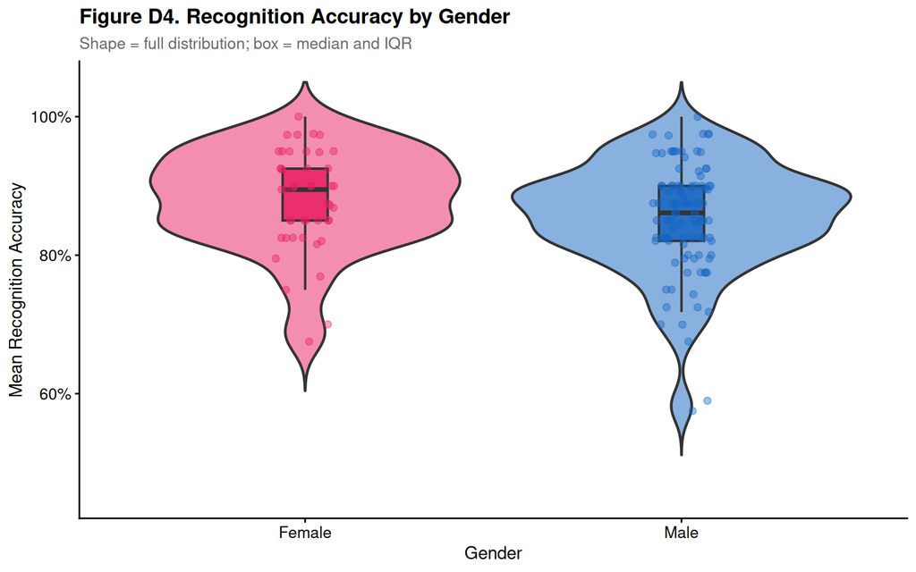

```r
p_d4 <- ggplot(participant_demo %>% filter(Gender %in% c("Female", "Male")),
               aes(x = Gender, y = mean_accuracy, fill = Gender)) +
  geom_violin(alpha = 0.5, trim = FALSE, linewidth = 0.8) +
  geom_boxplot(width = 0.12, outlier.shape = NA, alpha = 0.85, linewidth = 0.7) +
  geom_jitter(aes(colour = Gender), width = 0.08, alpha = 0.4, size = 1.8) +
  scale_fill_manual(values   = c("Female" = "#E91E63", "Male" = "#1565C0")) +
  scale_colour_manual(values = c("Female" = "#E91E63", "Male" = "#1565C0")) +
  scale_y_continuous(limits = c(0.45, 1.05), labels = scales::percent_format(accuracy = 1)) +
  labs(title = "Figure D4. Recognition Accuracy by Gender",
       subtitle = "Shape = full distribution; box = median and IQR",
       x = "Gender", y = "Mean Recognition Accuracy") +
  brsm_theme + theme(legend.position = "none")
print(p_d4)
```

### 5.2.5 Demographic Tests Summary Table

The table below summarises all four demographic tests. *Test ID* = test identifier (D1–D4); *Description* = what was being tested; *Test Type* = the statistical method used; *Test Statistic* = the computed value with degrees of freedom; *p-Value* = two-tailed probability; *Significant at p < .05* = whether the result passed the unadjusted alpha threshold of 0.05.

```r
tibble(
  `Test ID`                   = c("D1", "D2", "D3", "D4"),
  `Description`               = c(
    "Age balance between NB and AB conditions",
    "Gender balance between NB and AB conditions",
    "Correlation between age and recognition accuracy",
    "Difference in accuracy between female and male participants"
  ),
  `Statistical Test Used`     = c("Welch t-test", "Chi-squared test", "Pearson correlation", "Welch t-test"),
  `Test Statistic (with df)`  = c(
    sprintf("t(%.1f) = %.3f", td1$parameter, td1$statistic),
    sprintf("χ²(%d) = %.3f",  as.integer(td2$parameter), td2$statistic),
    sprintf("r = %.3f",        td3$estimate),
    sprintf("t(%.1f) = %.3f", td4$parameter, td4$statistic)
  ),
  `p-Value`                   = round(c(td1$p.value, td2$p.value, td3$p.value, td4$p.value), 4),
  `Significant at p < .05`    = c(td1$p.value, td2$p.value, td3$p.value, td4$p.value) < 0.05
)
```

| Test ID | Description | Statistical Test Used | Test Statistic (with df) | p-Value | Significant at p < .05 |
| --- | --- | --- | --- | --- | --- |
| D1 | Age balance between NB and AB conditions | Welch t-test | t(137.9) = 0.414 | 0.6792 | FALSE |
| D2 | Gender balance between NB and AB conditions | Chi-squared test | χ²(1) = 0.012 | 0.9135 | FALSE |
| D3 | Correlation between age and recognition accuracy | Pearson correlation | r = -0.128 | 0.1208 | FALSE |
| D4 | Difference in accuracy between female and male participants | Welch t-test | t(90.9) = 1.922 | 0.0577 | FALSE |

# 6 Results Summary

## 6.1 Summary Table of All Tests

The table below summarises the four primary hypothesis tests. *Dependent Variable* = what was measured; *Mean NB / Mean AB* = participant-level means for each condition; *t-Statistic* = Welch t-test value; *Degrees of Freedom* = Welch–Satterthwaite approximation; *p-Value* = two-tailed probability; *Significant* = whether p is below the Bonferroni-adjusted threshold of **0.0125** (not 0.05); *Cohen’s d* = standardised effect size (positive = NB > AB).

```r
tibble(
  `Hypothesis Test`             = c(
    "Test 1 — Overall recognition accuracy: NB vs AB",
    "Test 2 — Overall response time: NB vs AB",
    "Test 3 — Before-Boundary frame accuracy: NB vs AB",
    "Test 4 — Event-Middle frame accuracy: NB vs AB"
  ),
  `Dependent Variable`          = c(
    "Mean accuracy (proportion correct)",
    "Mean response time (seconds)",
    "Mean accuracy for BB frames only",
    "Mean accuracy for EM frames only"
  ),
  `Mean NB`                     = round(c(mean(acc_NB), mean(rt_NB, na.rm=TRUE), mean(bb_NB), mean(em_NB)), 3),
  `Mean AB`                     = round(c(mean(acc_AB), mean(rt_AB, na.rm=TRUE), mean(bb_AB), mean(em_AB)), 3),
  `t-Statistic`                 = round(c(t1$statistic, t2$statistic, t3$statistic, t4$statistic), 3),
  `Degrees of Freedom`          = round(c(t1$parameter, t2$parameter, t3$parameter, t4$parameter), 1),
  `p-Value`                     = round(c(t1$p.value,   t2$p.value,   t3$p.value,   t4$p.value),   4),
  `Significant (p < .0125)`     = c(t1$p.value, t2$p.value, t3$p.value, t4$p.value) < alpha_adjusted,
  `Cohen's d (effect size)`     = round(c(
    cohens_d_indep(acc_NB, acc_AB),
    cohens_d_indep(rt_NB[!is.na(rt_NB)], rt_AB[!is.na(rt_AB)]),
    cohens_d_indep(bb_NB, bb_AB),
    cohens_d_indep(em_NB, em_AB)
  ), 3)
)
```

| Hypothesis Test | Dependent Variable | Mean NB | Mean AB | t-Statistic | Degrees of Freedom | p-Value | Significant (p < .0125) | Cohen’s d (effect size) |
| --- | --- | --- | --- | --- | --- | --- | --- | --- |
| Test 1 — Overall recognition accuracy: NB vs AB | Mean accuracy (proportion correct) | 0.876 | 0.843 | 2.770 | 153.6 | 0.0063 | TRUE | 0.435 |
| Test 2 — Overall response time: NB vs AB | Mean response time (seconds) | 5.447 | 5.331 | 0.648 | 161.1 | 0.5179 | FALSE | 0.101 |
| Test 3 — Before-Boundary frame accuracy: NB vs AB | Mean accuracy for BB frames only | 0.863 | 0.826 | 2.324 | 155.1 | 0.0214 | FALSE | 0.365 |
| Test 4 — Event-Middle frame accuracy: NB vs AB | Mean accuracy for EM frames only | 0.890 | 0.860 | 2.259 | 153.6 | 0.0253 | FALSE | 0.355 |

## 6.2 Interpretation of Statistical Results

**Test 1 - Overall Accuracy (H1):** NB participants (M = 0.876) showed statistically significant higher recognition accuracy than AB participants (M = 0.843), t(153.6) = 2.770, p = 0.0063 (Bonferroni alpha = 0.0125). Cohen’s d = 0.435 (small effect). This supports **H1**: intact boundaries facilitate memory encoding.

**Test 2 - Overall RT (H1):** The RT difference between NB (M = 5.447 s) and AB (M = 5.331 s) was not statistically significant, t(161.1) = 0.648, p = 0.5179. Cohen’s d = 0.101 (negligible effect). Response times did not differ significantly between conditions.

**Test 3 - BB Accuracy (H2):** Restricting to BB frames, NB (M = 0.863) showed not statistically significant higher accuracy than AB (M = 0.826), t(155.1) = 2.324, p = 0.0214. Cohen’s d = 0.365 (small effect). The BB accuracy difference did not reach the adjusted threshold (partial support for H2).

**Test 4 - EM Accuracy (H3):** For EM frames, NB (M = 0.890) vs AB (M = 0.860) was not statistically significant, t(153.6) = 2.259, p = 0.0253. Cohen’s d = 0.355 (small effect). This supports **H3**: event-middle frames are not differentially affected by the boundary condition.

# 7 Conclusion and Future Directions

## 7.1 Summary of Findings

This study investigated whether disrupting a video before its natural event boundary impairs recognition memory (H1), whether boundary-adjacent frames are remembered better in the NB condition (H2), and whether event-middle frames are unaffected by the boundary manipulation (H3).

Four Welch t-tests tested these hypotheses at the participant level with Bonferroni-adjusted alpha = 0.0125. The four demographic tests (D1-D4) confirmed age- and gender-balanced groups and showed no demographic moderators of accuracy, supporting internal validity.

## 7.3 Future Directions

### 7.3.1 Analyses Feasible with Existing Data

The following extensions can be completed using the current dataset without additional data collection:

#### 7.3.1.1 1. **Confidence Rating Analysis**

We already collected confidence ratings (1-5 scale) but haven’t analyzed them. Can test: - Do NB participants express higher confidence than AB participants? - Is there a Condition × FrameType interaction on confidence? - Simple Welch t-tests comparing mean confidence: NB vs AB

#### 7.3.1.2 2. **Response Time Enhancement**

We tested overall RT (Test 2) but can extend: - RT by frame type: Are BB frames recognized faster than EM frames? - RT × Accuracy interaction: Do correct responses have different RT patterns than incorrect ones? - Violin plots showing RT distributions by condition and frame type

#### 7.3.1.3 3. **Mixed ANOVA for Condition × FrameType Interaction**

Currently we tested BB and EM separately (Tests 3 & 4). A proper mixed ANOVA would: - Test the **interaction** directly: Does the condition effect differ for BB vs EM frames? - More appropriate than separate t-tests for within-subjects factor (FrameType) - Can be done in R with `aov()` or `ezANOVA()`

#### 7.3.1.4 4. **Simple Demographic Interactions**

Using existing demographic data, test whether treatment effect varies by: - **Condition × Gender**: Does the NB advantage differ for males vs females? - Split sample into Male/Female, compute NB-AB difference for each - Independent t-test comparing the difference scores - Visualization: interaction plot - **Condition × Age Group**: Split age into 2-3 groups (e.g., 18-21, 22-25, 26+) - Test if younger vs older participants show different boundary sensitivity

#### 7.3.1.5 5. **Effect Size Contextualization**

We report Cohen’s *d* but haven’t interpreted it relative to the literature: - Compare our effect sizes to published event segmentation studies - Brief literature search (~10 relevant papers) - Add 2-3 sentences contextualizing whether our effects are typical/smaller/larger

#### 7.3.1.6 6. **Recognition Memory Index (REC)**

Currently using raw accuracy. REC corrects for guessing/response bias: - Formula: REC = (Hits + Correct Rejections) / Total Trials - 0.5 - Or: Hit Rate - False Alarm Rate (if we have lure trials coded separately) - Rerun primary analyses with REC instead of raw accuracy

#### 7.3.1.7 7. **Additional Visualizations**

- Raincloud plots (density + boxplot + individual points combined)
- Interaction plots showing Condition × FrameType
- Confidence × Accuracy calibration scatter plots
- Cumulative distribution functions (CDF) for RT

#### 7.3.1.8 8. **Video Stimuli Analysis**

Using the video metadata files (duration, repeat status): - Do repeated videos show better recognition? (is_repeat = 1) - Does video duration correlate with recognition accuracy? - Are certain videos consistently easier/harder across participants? - Item-level difficulty analysis

# 8 References

Swallow, K. M., Zacks, J. M., & Abrams, R. A. (2009). Event boundaries in perception affect memory encoding and updating. *Journal of Experimental Psychology: General*, *138*(2), 236-257. https://doi.org/10.1037/a0015631

Zacks, J. M., Speer, N. K., Swallow, K. M., Braver, T. S., & Reynolds, J. R. (2007). Event perception: A mind-brain perspective. *Psychological Bulletin*, *133*(2), 273-293. https://doi.org/10.1037/0033-2909.133.2.273

*Report generated with R 4.5.2 on 2026-03-10.*